# R Notebook

Scientific Question: What mutations and alternate splicing differences in DNA sequence exist between different variants of the gene FRMD4A, and how does that impact the homology in the structures of the protein?

Background: My gene of interest is the FERM Domain Containing 4A (FRMD4A) gene. Previous research has shown a correlation between miss regulation of the FRMD4A gene, in particularly up regulation, and oral squamous cell carcinoma. As an inspiring dentist I am interested in oral squamous cell carcinoma and ways to prevent it. By understanding which variants of the FRMD4A gene have mutated protein structures that alter the function of the FRMD4A gene we can target those genes for therapy and treat for oral squamous cell carcinoma from very early stages. DNA sequence of the four FRMD4A variants are extracted from the ncbi nucleotides database. The protein structures used for the homology modeling were extracted from SWISS protein and PDB.

Scientific Hypothesis: If the sequences of the four FRMD4A gene variants are altered through mutations and/or alternate splicing then they will exhibit differences in their protein structures.

```r
library(Biostrings)
library(msa)
```

- Biostrings is used for uncoding and reading long strings of data. In this case biostrings is helpful in reading and maninpulating the nucelotide sequences.
- msa is used for multiple sequence alignment and includes a function called “msa pretty print” that cleans up the alignment.

```r
system.file("tex", "texshade.sty", package="msa")
```

```
[1] "/Library/Frameworks/R.framework/Versions/4.1/Resources/library/msa/tex/texshade.sty"
```

```r
FRMD4A_unaligned <- readAAStringSet("Wildtype.fasta")

Kinase_MSA <- msa(FRMD4A_unaligned)
```

```
use default substitution matrix
```

```r
print(Kinase_MSA, show="complete")
```

```
MsaAAMultipleAlignment with 4 rows and 3219 columns
    aln (1..91)                                                                                 names
[1] ATGGTGGTT------CAGGCTGCAGTGGCTCCGAATAG-------ATCCCAAAGACTTTTACTGAAAATTCCTTATGGATCTCTGAGAAGG lcl|NC_000010.11_...
[2] ------------------------------------------------------------------------------------------- lcl|NC_000010.11_...
[3] ATGGCAGTG------CAG----CTGGTGCCCGACTCAG-------CTCTCGG------------------CCTGCTG-------------- lcl|NC_000010.11_...
[4] ATGGCTGCTGGGCTGCTTGGCTCTGAGGACCCACCGTGGAGTTGGAACCTGACTTGTCGGGCGCTGAGGACCTGCCAAGTGAGGAACATTC lcl|NC_000010.11_...
Con ATGGC?GTT------CAG?---CTG?GGCCCCAC??AG-------ATCCCGA----?----?----?---CCTGCTG--?-----?-?--- Consensus

    aln (92..182)                                                                               names
[1] --------------------------------------CGCAGCGTTGAAAGGATGACGGAGGGCCGCCGATGTCAAGTACATCTTCTTGA lcl|NC_000010.11_...
[2] ------------------------------------------------------------------------------------------- lcl|NC_000010.11_...
[3] --------------------------------------------------ATGATGACGGAGGGCCGCCGATGTCAAGTACATCTTCTTGA lcl|NC_000010.11_...
[4] GAGTTCTGCAGCTGCTGCTAAAACCATGGTGCATCTCCAGGGCCGTCTATCAGATGACGGAGGGCCGCCGATGTCAAGTACATCTTCTTGA lcl|NC_000010.11_...
Con ---------------------------------------?---???--?-A?GATGACGGAGGGCCGCCGATGTCAAGTACATCTTCTTGA Consensus

    aln (183..273)                                                                              names
[1] TGACAGGAAGCTGGAACTCCTAGTACAGCCCAAGCTGTTGGCCAAGGAGCTTCTTGACCTTGTGGCTTCTCACTTCAATCTGAAGGAAAAG lcl|NC_000010.11_...
[2] ------------------------------------------------------------------------------------------- lcl|NC_000010.11_...
[3] TGACAGGAAGCTGGAACTCCTAGTACAGCCCAAGCTGTTGGCCAAGGAGCTTCTTGACCTTGTGGCTTCTCACTTCAATCTGAAGGAAAAG lcl|NC_000010.11_...
[4] TGACAGGAAGCTGGAACTCCTAGTACAGCCCAAGCTGTTGGCCAAGGAGCTTCTTGACCTTGTGGCTTCTCACTTCAATCTGAAGGAAAAG lcl|NC_000010.11_...
Con TGACAGGAAGCTGGAACTCCTAGTACAGCCCAAGCTGTTGGCCAAGGAGCTTCTTGACCTTGTGGCTTCTCACTTCAATCTGAAGGAAAAG Consensus

    aln (274..364)                                                                              names
[1] GAGTACTTTGGAATAGCATTCACAGATGAAACGGGACACTTAAACTGGCTTCAGCTAGATCGAAGAGTATTGGAACATGACTTCCCTAAAA lcl|NC_000010.11_...
[2] ------------------------------------------------------------------------------------------- lcl|NC_000010.11_...
[3] GAGTACTTTGGAATAGCATTCACAGATGAAACGGGACACTTAAACTGGCTTCAGCTAGATCGAAGAGTATTGGAACATGACTTCCCTAAAA lcl|NC_000010.11_...
[4] GAGTACTTTGGAATAGCATTCACAGATGAAACGGGACACTTAAACTGGCTTCAGCTAGATCGAAGAGTATTGGAACATGACTTCCCTAAAA lcl|NC_000010.11_...
Con GAGTACTTTGGAATAGCATTCACAGATGAAACGGGACACTTAAACTGGCTTCAGCTAGATCGAAGAGTATTGGAACATGACTTCCCTAAAA Consensus

    aln (365..455)                                                                              names
[1] AGTCAGGACCCGTGGTTTTATACTTTTGTGTCAGGTTCTATATAGAAAGCATTTCATACCTGAAGGATAATGCTACCATTGAGCTTTTCTT lcl|NC_000010.11_...
[2] ------------------------------------------------------------------------------------------- lcl|NC_000010.11_...
[3] AGTCAGGACCCGTGGTTTTATACTTTTGTGTCAGGTTCTATATAGAAAGCATTTCATACCTGAAGGATAATGCTACCATTGAGCTTTTCTT lcl|NC_000010.11_...
[4] AGTCAGGACCCGTGGTTTTATACTTTTGTGTCAGGTTCTATATAGAAAGCATTTCATACCTGAAGGATAATGCTACCATTGAGCTTTTCTT lcl|NC_000010.11_...
Con AGTCAGGACCCGTGGTTTTATACTTTTGTGTCAGGTTCTATATAGAAAGCATTTCATACCTGAAGGATAATGCTACCATTGAGCTTTTCTT Consensus

    aln (456..546)                                                                              names
[1] TCTGAACGCGAAGTCCTGCATCTACAAGGAGCTTATTGACGTTGACAGCGAAGTGGTGTTTGAATTAGCTTCCTATATTTTACAGGAGGCA lcl|NC_000010.11_...
[2] ------------------------------------------------------------------------------------------- lcl|NC_000010.11_...
[3] TCTGAACGCGAAGTCCTGCATCTACAAGGAGCTTATTGACGTTGACAGCGAAGTGGTGTTTGAATTAGCTTCCTATATTTTACAGGAGGCA lcl|NC_000010.11_...
```

[output cut: 197 more lines]

```
Con GCGCACAGCAGGGTCACCAGGATGCCCCAGATGTGCAAGGCCACGTCAGCTGCCTTACCTCAAAGCCAGAGAAGCTCGACACCGTCAAGTG Consensus

    aln (3095..3185)                                                                            names
[1] AAATTGGAGCCACCCCCCCAAGCAGCCCCCACCACATCCTAACCTGGCAGACTGGAGAAGCAACAGAAAACTCACCCATTCTGGATGGGTC lcl|NC_000010.11_...
[2] AAATTGGAGCCACCCCCCCAAGCAGCCCCCACCACATCCTAACCTGGCAGACTGGAGAAGCAACAGAAAACTCACCCATTCTGGATGGGTC lcl|NC_000010.11_...
[3] AAATTGGAGCCACCCCCCCAAGCAGCCCCCACCACATCCTAACCTGGCAGACTGGAGAAGCAACAGAAAACTCACCCATTCTGGATGGGTC lcl|NC_000010.11_...
[4] AAATTGGAGCCACCCCCCCAAGCAGCCCCCACCACATCCTAACCTGGCAGACTGGAGAAGCAACAGAAAACTCACCCATTCTGGATGGGTC lcl|NC_000010.11_...
Con AAATTGGAGCCACCCCCCCAAGCAGCCCCCACCACATCCTAACCTGGCAGACTGGAGAAGCAACAGAAAACTCACCCATTCTGGATGGGTC Consensus

    aln (3186..3219)                   names
[1] TGAGTCTCCACCTCACCAAAGTACTGATGAATAG lcl|NC_000010.11_...
[2] TGAGTCTCCACCTCACCAAAGTACTGATGAATAG lcl|NC_000010.11_...
[3] TGAGTCTCCACCTCACCAAAGTACTGATGAATAG lcl|NC_000010.11_...
[4] TGAGTCTCCACCTCACCAAAGTACTGATGAATAG lcl|NC_000010.11_...
Con TGAGTCTCCACCTCACCAAAGTACTGATGAATAG Consensus
```

```r
msaPrettyPrint(Kinase_MSA, output="tex", showNames="left", showLogo="top",
logoColors="rasmol", shadingMode="functional", shadingModeArg="structure",
showLegend=FALSE, askForOverwrite=FALSE)
```

Homology Modeling

```r
library(bio3d)
```

bio3d is a package that allows us to analyze the structures of proteins.

```r
pdb <- read.pdb("1e5w.1.pdb")
print(pdb)
```

```
 Call:  read.pdb(file = "1e5w.1.pdb")

   Total Models#: 1
     Total Atoms#: 2925,  XYZs#: 8775  Chains#: 2  (values: A -)

     Protein Atoms#: 2889  (residues/Calpha atoms#: 346)
     Nucleic acid Atoms#: 0  (residues/phosphate atoms#: 0)

     Non-protein/nucleic Atoms#: 36  (residues: 2)
     Non-protein/nucleic resid values: [ HOH (2) ]

   Protein sequence:
      MPKTISVRVTTMDAELEFAIQPNTTGKQLFDQVVKTIGLREVWFFGLQYQDTKGFSTWLK
      LNKKVTAQDVRKESPLLFKFRAKFYPEDVSEELIQDITQRLFFLQVKEGILNDDIYCPPE
      TAVLLASYAVQSKYGDFNKEVHKSGYLAGDKLLPQRVLEQHKLNKDQWEERIQVWHEEHR
      GMLREDAVLEYLKIAQDLEMYGVNYFSIKNKKGSELWLGVDALGL...<cut>...EKEE

+ attr: atom, xyz, calpha, call
```

```r
head(pdb$atom)
```

|  | type | eleno | elety | alt | resid | chain | resno | insert | x | y | z | o | b | segid | elesy | charge |
| --- | --- | --- | --- | --- | --- | --- | --- | --- | --- | --- | --- | --- | --- | --- | --- | --- |
| 1 | ATOM | 1 | N | NA | MET | A | 1 | NA | 23.019 | -20.525 | 39.577 | 1 | 109.13 | NA | N | NA |
| 2 | ATOM | 2 | CA | NA | MET | A | 1 | NA | 24.389 | -20.878 | 39.108 | 1 | 96.43 | NA | C | NA |
| 3 | ATOM | 3 | C | NA | MET | A | 1 | NA | 25.093 | -19.718 | 38.394 | 1 | 96.62 | NA | C | NA |
| 4 | ATOM | 4 | O | NA | MET | A | 1 | NA | 25.995 | -19.112 | 38.976 | 1 | 93.40 | NA | O | NA |
| 5 | ATOM | 5 | CB | NA | MET | A | 1 | NA | 24.347 | -22.098 | 38.170 | 1 | 85.67 | NA | C | NA |
| 6 | ATOM | 6 | CG | NA | MET | A | 1 | NA | 25.715 | -22.494 | 37.598 | 1 | 82.77 | NA | C | NA |

```r
print(pdb$xyz)
```

```
   Total Frames#: 1
   Total XYZs#:   8775,  (Atoms#:  2925)

    [1]  23.019  -20.525  39.577  <...>  8.503  14.975  33.762  [8775]

+ attr: Matrix DIM = 1 x 8775
```

```r
modes <- nma(pdb)
```

```
 Building Hessian...        Done in 0.637 seconds.
 Diagonalizing Hessian...   Done in 7.104 seconds.
```

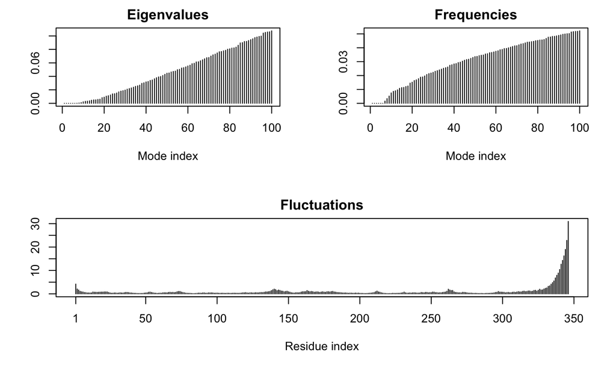

```r
plot(modes)
```

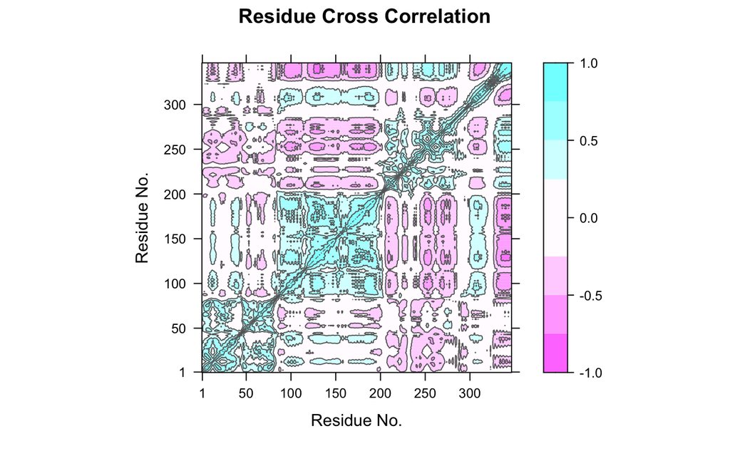

```r
cm <- dccm(modes)
plot (cm, sse=pdb)
```

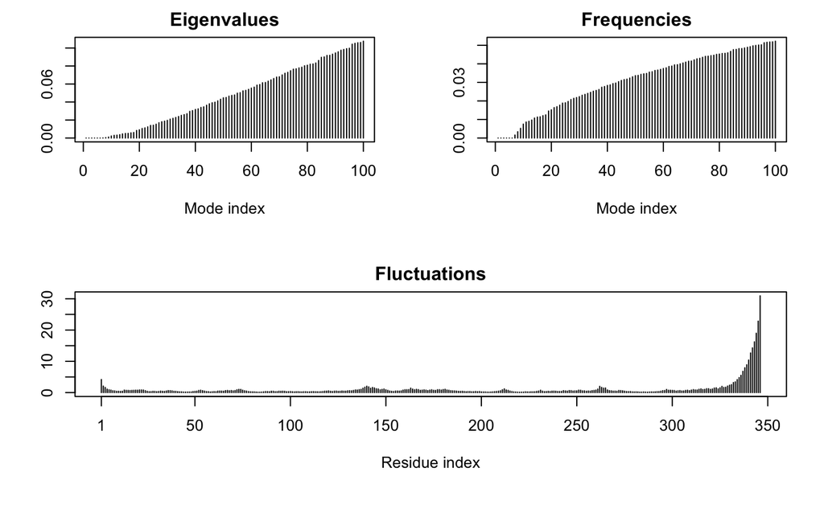

```r
plot(modes, sse=pdb)
```

```r
modes.anm <- nma(pdb, ff= "anm")
```

```
 Building Hessian...        Done in 0.25 seconds.
 Diagonalizing Hessian...   Done in 7.605 seconds.
```

```r
r <- rmsip(modes, modes.anm)
```

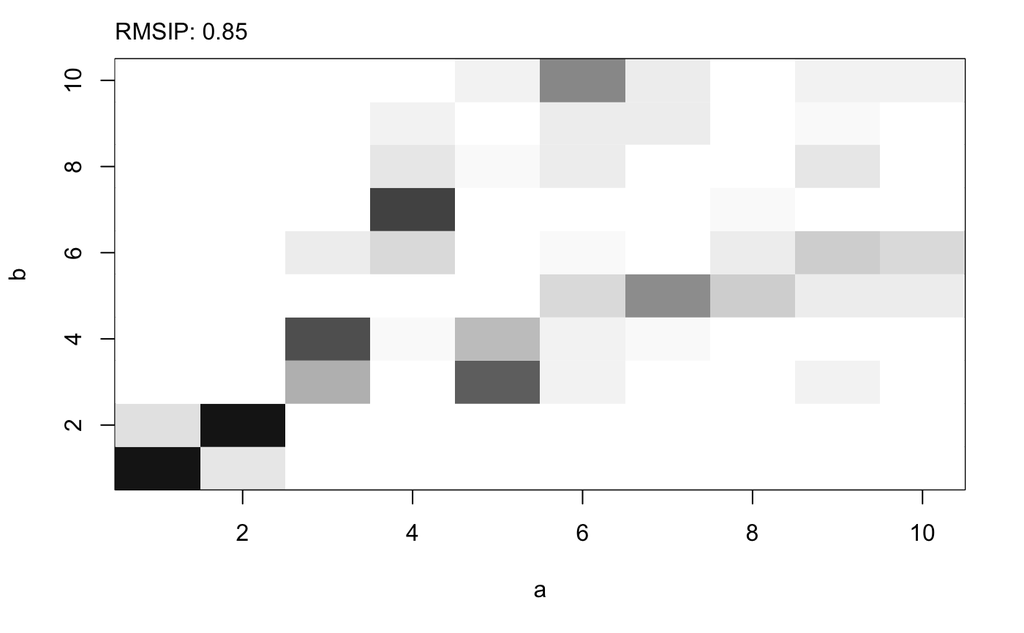

```r
plot(r)
```

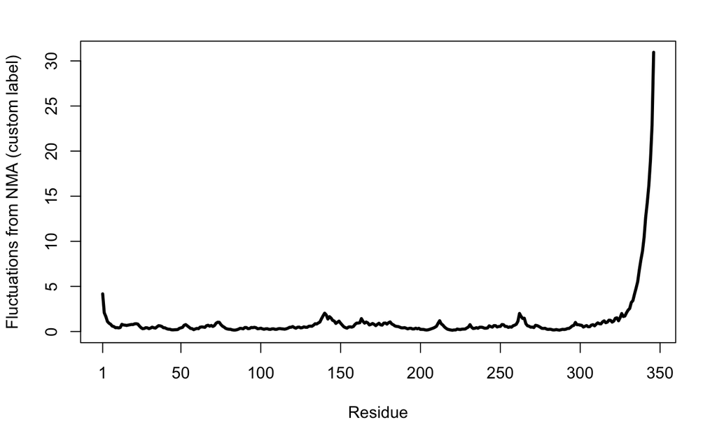

```r
plot.bio3d(modes$fluctuations, sse=pdb, sheet.col="orange", helix.col="purple", typ="l", lwd=3, ylab="Fluctuations from NMA (custom label)")
```

```r
ids <- c("3u8z", "5xq0", "4cgk", "1e5w")
```

```r
raw.files <- get.pdb(ids)
```

```r
files1 <- pdbsplit(raw.files, ids)
```

```r
library(msa)
pdbs <- pdbaln(files1, exefile='msa')
```

```
Reading PDB files:
split_chain/3u8z_A.pdb
split_chain/3u8z_B.pdb
split_chain/3u8z_C.pdb
split_chain/3u8z_D.pdb
split_chain/5xq0_A.pdb
split_chain/5xq0_B.pdb
split_chain/4cgk_A.pdb
split_chain/4cgk_B.pdb
split_chain/1e5w_A.pdb
.......   PDB has ALT records, taking A only, rm.alt=TRUE
..

Extracting sequences

pdb/seq: 1   name: split_chain/3u8z_A.pdb
pdb/seq: 2   name: split_chain/3u8z_B.pdb
pdb/seq: 3   name: split_chain/3u8z_C.pdb
pdb/seq: 4   name: split_chain/3u8z_D.pdb
pdb/seq: 5   name: split_chain/5xq0_A.pdb
pdb/seq: 6   name: split_chain/5xq0_B.pdb
pdb/seq: 7   name: split_chain/4cgk_A.pdb
pdb/seq: 8   name: split_chain/4cgk_B.pdb
   PDB has ALT records, taking A only, rm.alt=TRUE
pdb/seq: 9   name: split_chain/1e5w_A.pdb
```

```r
summary(c(seqidentity(pdbs)))
```

```
   Min. 1st Qu.  Median    Mean 3rd Qu.    Max.
 0.1130  0.1320  0.1880  0.4556  1.0000  1.0000
```

```r
modes2 <- nma.pdbs(pdbs, fit = TRUE, outpath= NULL)
```

```
Details of Scheduled Calculation:
  ... 9 input structures
  ... storing 618 eigenvectors for each structure
  ... dimension of x$U.subspace: ( 624x618x9 )
  ... coordinate superposition prior to NM calculation
  ... aligned eigenvectors (gap containing positions removed)
  ... estimated memory usage of final 'eNMA' object: 26.5 Mb
```

```
Extracting SSE from pdbs$sse attribute
```

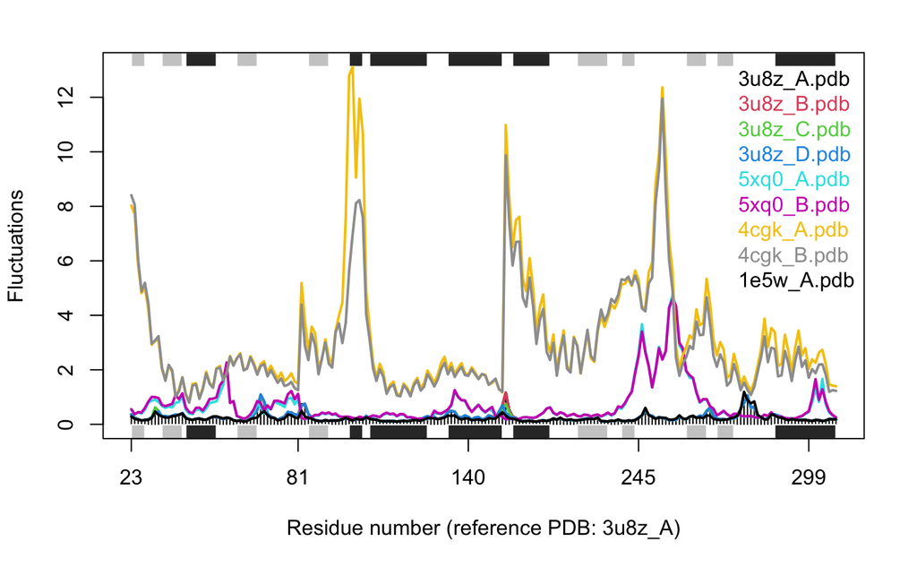

```r
plot(modes2, pdbs, type="h")
```

```r
print(modes2)
```

```
Call:
  nma.pdbs(pdbs = pdbs, fit = TRUE, outpath = NULL)

Class:
  enma

Number of structures:
  9

Attributes stored:
  - Root mean square inner product (RMSIP)
  - Aligned atomic fluctuations
  - Aligned eigenvectors (gaps removed)
  - Dimensions of x$U.subspace: 624x618x9

Coordinates were aligned prior to NMA calculations

+ attr: fluctuations, rmsip, U.subspace, L, full.nma, xyz,
        call
```

```r
modes2$rmsip
```

```
           3u8z_A.pdb 3u8z_B.pdb 3u8z_C.pdb 3u8z_D.pdb 5xq0_A.pdb 5xq0_B.pdb 4cgk_A.pdb 4cgk_B.pdb 1e5w_A.pdb
3u8z_A.pdb     1.0000     0.9996     0.9889     0.9940     0.4136     0.4249     0.3540     0.3637     0.8967
3u8z_B.pdb     0.9996     1.0000     0.9879     0.9938     0.4142     0.4254     0.3545     0.3639     0.8967
3u8z_C.pdb     0.9889     0.9879     1.0000     0.9834     0.4197     0.4309     0.3600     0.3685     0.9084
3u8z_D.pdb     0.9940     0.9938     0.9834     1.0000     0.4160     0.4274     0.3550     0.3633     0.8992
5xq0_A.pdb     0.4136     0.4142     0.4197     0.4160     1.0000     0.9920     0.3861     0.3997     0.4280
5xq0_B.pdb     0.4249     0.4254     0.4309     0.4274     0.9920     1.0000     0.3912     0.4044     0.4399
4cgk_A.pdb     0.3540     0.3545     0.3600     0.3550     0.3861     0.3912     1.0000     0.9791     0.3791
4cgk_B.pdb     0.3637     0.3639     0.3685     0.3633     0.3997     0.4044     0.9791     1.0000     0.3859
1e5w_A.pdb     0.8967     0.8967     0.9084     0.8992     0.4280     0.4399     0.3791     0.3859     1.0000
```

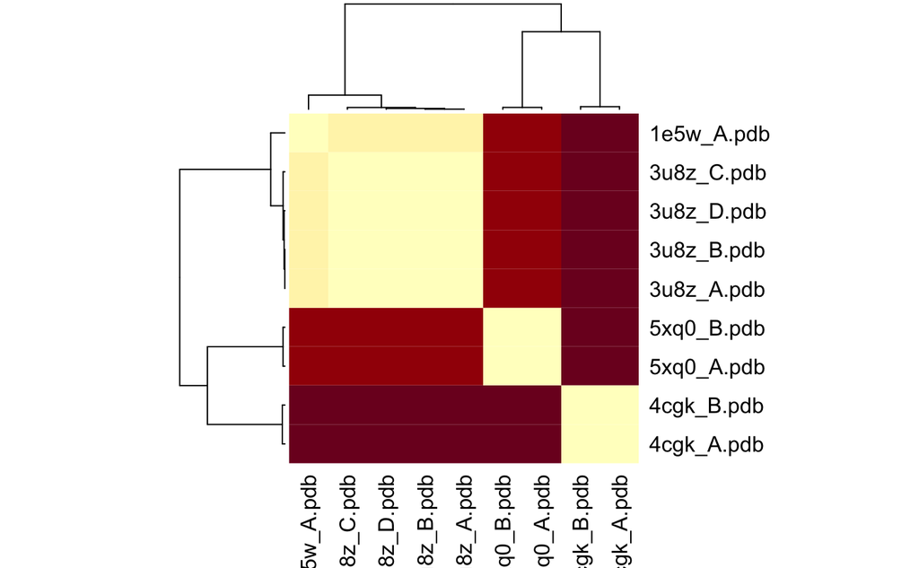

```r
heatmap(1-modes2$rmsip, symm = TRUE)
```